# Supplement to the MSstats+ benchmark review

Reproducible CSF Spectronaut sample-swap and protein-swap diagnostics

Author

Witold Wolski

Published

May 21, 2026

# 1 Supplement Scope

This supplement provides the technical material supporting the short main review. It contains the reproduced CSF Spectronaut benchmark tables, p-value distribution diagnostics, per-protein effect-size and within-condition variance checks, rebuilt sample-swap analyses, protein-swap sensitivity analyses, and an author-facing list of points to address.

The rebuilt sample-swap and protein-swap analyses are not proposed as definitive replacement benchmarks. They are sensitivity checks for the main review concern: the manuscript’s K562/CSF sample-swap benchmark can couple ground-truth class to within-condition variance, which complicates the interpretation of method rankings in Table 1.

The central critique is not that MSstats+ is implemented incorrectly. The central critique is that the sample-swap construction can induce a label-dependent variance structure. The CSF benchmark starts from a dilution experiment where the Neat versus 1:2 comparison should make almost every quantified protein differentially abundant. There is therefore no natural null class. The benchmark creates a null by swapping run labels for most proteins and leaving a minority unchanged as Positives. This gives a useful synthetic stress-test benchmark, but it also links the ground-truth label to within-condition variance: Positives remain relatively clean dilution comparisons, while Negatives become mixtures of dilution levels inside each condition.

This matters for methods that use empirical-Bayes or related variance moderation. In the sample-swap benchmark, the shared variance prior is estimated from an imbalanced mixture dominated by Negative proteins. If the Negative class has higher within-condition variance because of the swap construction, moderation can pull the Positive variances upward and reduce sensitivity. This supports the main review conclusion: Table 1 should be interpreted as evidence for performance on this specific sample-swap construction, not as a standalone general ranking of differential-abundance workflows.

This supplement reports two operating points, both at threshold 0.05: raw p-value and adjusted p-value. TPR is the fraction of truth-set Positives detected. PPV is one minus the false-positive fraction among called proteins. Missing model outputs appear as missing values in the result tables.

The review code is available at https://github.com/wolski/msstatsplus-quant-review. See the repository [`README.md`](https://github.com/wolski/msstatsplus-quant-review/blob/main/README.md) for the project layout, including shared R code in `R/`, helper scripts in `src/`, and review sources in `vignettes/`.

The GitHub repository contains code and review sources, not the raw benchmark data. The input data are from the public MSstats+ archive: ProteomeXchange [`PXD066486`](https://proteomecentral.proteomexchange.org/cgi/GetDataset?ID=PXD066486) and MassIVE [`MSV000098622`](https://massive.ucsd.edu/ProteoSAFe/dataset.jsp?task=fdf984642108451cbdece7303e47f2d2), with files available from the MassIVE FTP archive `ftp://massive-ftp.ucsd.edu/v10/MSV000098622/`.

# 2 Benchmark Data And Truth Sets

The authors’ CSF Spectronaut benchmark uses a 1,820-protein truth list: 182 Positives and 1,638 Negatives. In the re-run workflow, I also created two checks that use the same underlying CSF Spectronaut report but different synthetic truth definitions.

First, the rebuilt sample-swap benchmark applies the sample-swap idea in a single generated report rather than inside individual modelling scripts. Second, the protein-swap benchmark swaps precursor intensities between matched protein pairs instead of swapping sample labels. Both rebuilt benchmarks now use the same conservative universe: proteins in non-blank runs with at least two unique precursors. The original report contains 3,041 non-blank proteins with at least one precursor; applying `n_precursors >= 2` leaves 2,244 proteins. The excluded 797 proteins are single-precursor proteins. Keeping this filter is a design choice: single-precursor proteins are less stable as benchmark Negatives, and they cannot participate in the matched protein-pair construction.

The rebuilt sample-swap truth list therefore contains 2,244 proteins: 224 Positives and 2,020 Negatives. The protein-swap truth list contains the same 2,244-protein universe, with 224 Positives arranged as 112 matched protein pairs and 2,020 Negatives.

Truth sets used by this review.

| Truth_set | Rows | Positives | Negatives |
| --- | --- | --- | --- |
| Authors’ CSF sample-swap list | 1820 | 182 | 1638 |
| Protein-swap list | 2244 | 224 | 2020 |
| Rebuilt sample-swap list | 2244 | 224 | 2020 |

# 3 Authors’ CSF Spectronaut Benchmark

The authors’ CSF Spectronaut analysis has both expected log2 cells available: `all_data` and `good_data`. These are the closest reproduction of the manuscript-style CSF sample-swap benchmark in this report.

The `good_data` subset is especially important because it restricts the comparison to the cleaner Neat and 1:2 runs. If the benchmark were a neutral standard differential-abundance problem, the non-MSstats workflows should behave similarly across clean benchmark constructions. Instead, the sample-swap construction remains important because the Negative class has been made by mixing dilution levels inside condition.

## 3.1 CSF all_data, log2

Authors’ CSF sample-swap benchmark: all_data/log2.

| Package | N | TPR_raw_p | PPV_raw_p | TPR_FDR | PPV_FDR |
| --- | --- | --- | --- | --- | --- |
| MSstats | 1786 | 0.777 | 1.000 | 0.000 | NA |
| MSstats+ | 1786 | 0.983 | 0.994 | 0.897 | 1 |
| MaxLFQ_limma | 1786 | 0.880 | 1.000 | 0.000 | NA |
| DEqMS | 1786 | 0.857 | 0.993 | 0.000 | NA |
| msqrob2 | 1786 | 0.966 | 1.000 | 0.006 | 1 |
| prolfqua | 1786 | 0.971 | 0.994 | 0.411 | 1 |
| limpa | 1786 | 0.714 | 1.000 | 0.000 | NA |

Table 2 is the manuscript Table 1 replication check for the CSF Spectronaut sample-swap benchmark. The manuscript-comparable columns are the raw p-value columns (`TPR_raw_p` and `PPV_raw_p`), evaluated at threshold 0.05 because that is the operating point used in the original benchmark summary. At this operating point, the rerun agrees with the manuscript for the reproduced authors’ pipeline rows: MSstats, MaxLFQ+limma, DEqMS, and limpa. MSstats+ is also very close to the manuscript value, with only a small numerical difference in this current render.

The `msqrob2` row should not be interpreted as a failed replication. In this rerun we deliberately use a different, faster `msqrob2` pipeline than the one used for the manuscript/original archive. A difference in the `msqrob2` TPR is therefore expected and is not evidence that the CSF sample-swap replication failed. The FDR columns are additional review diagnostics and are not the manuscript Table 1 operating point.

The p-value distributions for Table 2 are shown below. The dashed vertical line marks the 0.05 threshold used for the raw p-value columns.

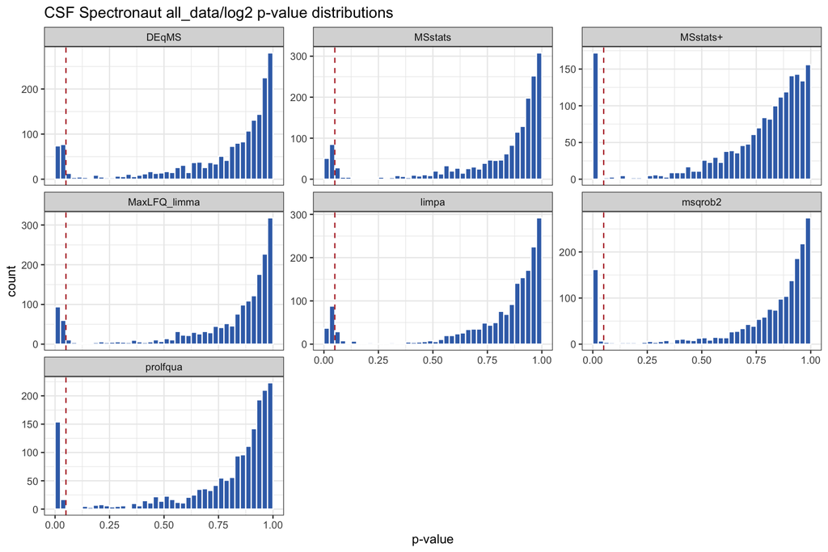

P-value distributions for Table 2: authors’ CSF Spectronaut all_data/log2 benchmark. The dashed red line marks p = 0.05.

Figure 1 is an additional diagnostic for benchmark calibration. Because the authors’ sample-swap truth list is dominated by Negatives, the overall p-value histograms are driven mainly by proteins intended to behave as null proteins. Under a well-calibrated null, those H0 p-values should be approximately uniform on `[0, 1]`. Instead, the CSF all_data/log2 distributions are strongly non-uniform across methods. Most panels show substantial mass near one, while several also show method-dependent spikes near zero.

This pattern should be interpreted cautiously. A non-uniform p-value histogram does not by itself identify the cause, and the all_data benchmark intentionally contains poor-quality high-dilution runs. However, the pattern is anomalous for a clean null benchmark and is consistent with the broader concern that the sample-swap construction changes more than the null mean. It motivates the variance diagnostics below, where the same benchmark is shown to couple the truth label to within-condition variance.

## 3.2 CSF good_data, log2

Here `good_data` means the authors’ CSF Spectronaut benchmark restricted to the Good runs from the canonical Neat versus 1:2 comparison, with balanced replicate counts. It excludes the higher-dilution Bad runs present in `all_data`. The sample-swap truth definition is otherwise unchanged: Negative proteins are still created by the authors’ in-script sample-label swap, while Positive proteins retain the original dilution comparison.

Authors’ CSF sample-swap benchmark: good_data/log2.

| Package | N | TPR_raw_p | PPV_raw_p | TPR_FDR | PPV_FDR |
| --- | --- | --- | --- | --- | --- |
| MSstats | 1786 | 0.983 | 1.000 | 0.971 | 1 |
| MSstats+ | 1786 | 0.983 | 1.000 | 0.971 | 1 |
| MaxLFQ_limma | 1786 | 0.983 | 0.983 | 0.977 | 1 |
| DEqMS | 1786 | 0.983 | 0.977 | 0.971 | 1 |
| msqrob2 | 1786 | 0.977 | 0.977 | 0.971 | 1 |
| prolfqua | 1786 | 0.983 | 0.983 | 0.960 | 1 |
| limpa | 1786 | 0.989 | 1.000 | 0.960 | 1 |

# 4 Per-protein Effect Size And Within-condition Variance

The sample-swap operation solves one problem and creates another. It solves the absence of a null class by exchanging Negative-protein measurements between paired Condition1 and Condition2 runs. At the condition level, each Negative protein then has approximately the same mean in both groups. The Positive proteins are not swapped and keep the original dilution effect.

The variance-shrinkage story sits here. Under H0, Negative proteins should have within-condition variance approximately equal to Positive proteins because both classes are technical dilutions of the same material. The swap induces a bimodal variance distribution tied to the ground-truth label:

- **Positive proteins** retain their natural per-run variance because no runs were rewritten for them.
- **Negative proteins** become 50/50 mixtures of Neat and 1:2 runs inside each condition, so their within-condition variance grows by the mixture term `0.5 * 0.5 * 1^2` in log2 units.

The following figures are generated from the authors’ CSF Spectronaut benchmark implementation, not from our rebuilt explicit sample-swap file. They use the MSstats protein-level summary object `CSF_Spectronaut/good_data/log2/swap/MSstats/MSstats_summarized.rda`; the plotted variable is `LogIntensities`, already on the log2 scale. The after-swap state is created in memory with the same `swap_condition_labels()` operation used by the authors’ MSstats benchmark code. This object matches the authors’ benchmark code path and is therefore the relevant object for evaluating the Table 1 CSF result.

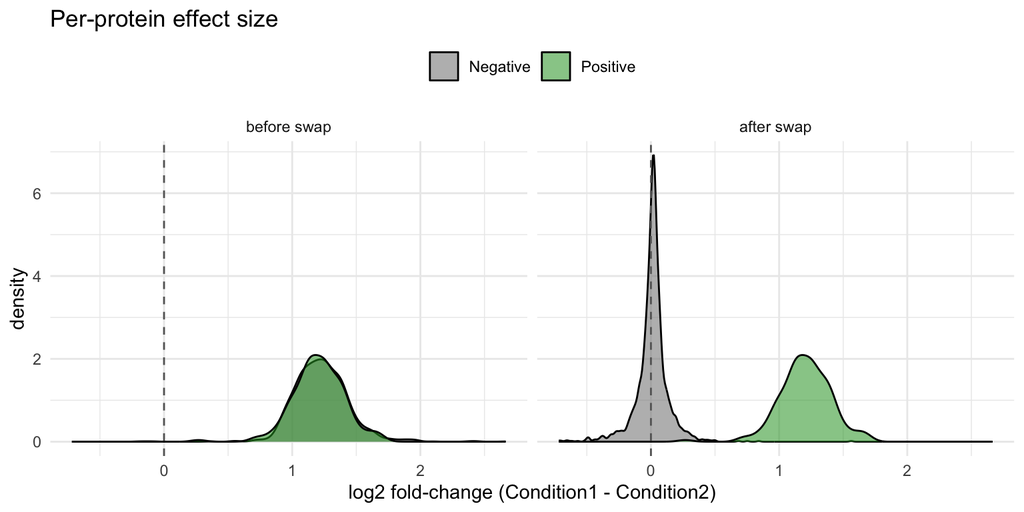

Authors’ CSF sample-swap benchmark, good_data/log2. Per-protein effect size is the mean MSstats protein-level LogIntensities in Condition1 minus Condition2. Before the swap, both classes carry the dilution effect; after the authors’ in-memory sample swap, Negative proteins are centered near zero while Positive proteins retain the dilution effect.

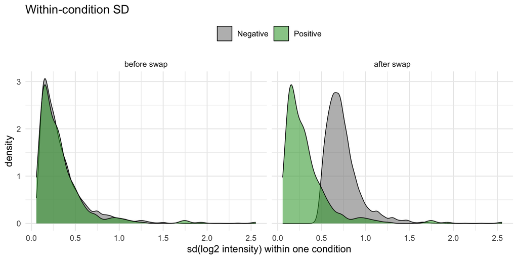

Authors’ CSF sample-swap benchmark, good_data/log2. For each protein and condition, SD is computed across runs from the same MSstats protein-level LogIntensities. The density shows these condition-specific SD values by class. After the swap, the Negative class shifts to higher within-condition SD because each condition contains a mixture of Neat and 1:2 measurements for Negative proteins; Positive proteins are not swapped.

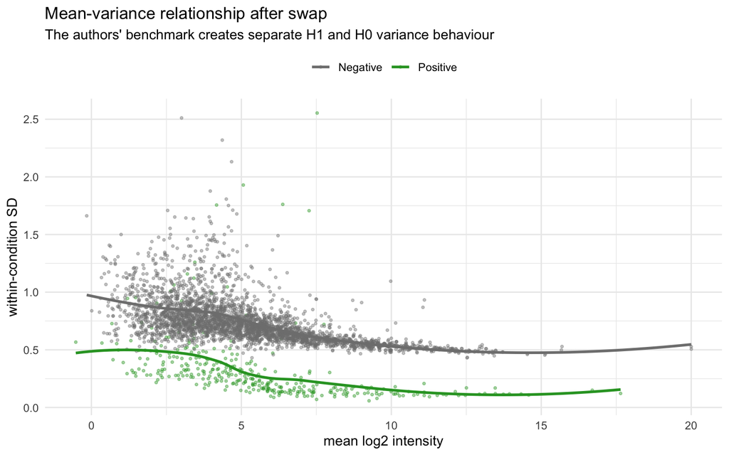

Authors’ CSF sample-swap benchmark, good_data/log2. Each point is one protein within one condition after the in-memory sample swap. The x-axis is the condition-specific mean MSstats protein-level LogIntensity and the y-axis is the condition-specific SD across runs. No pooled SD is used. The two trends show the variance structure that can disadvantage empirical-Bayes methods using one shared moderation trend.

The mixture-induced variance asymmetry provides a mechanism by which moderated methods (limma, DEqMS, msqrob2, limpa) can shrink **Positive** proteins more than Negative ones. The empirical-Bayes prior can be influenced by the Negative-dominated variance regime and can sit farther above the Positive variance than below the Negative variance. The expected consequence is reduced sensitivity for the Positive class, rather than inflated specificity.

**Sample-size dependence.** The strength of the moderation prior depends on degrees of freedom. With many replicates, the per-protein variance estimate dominates the prior; with few replicates, the prior dominates. A 4-vs-4 design therefore puts the prior at much higher relative weight than a larger balanced design, so `small_good_data` accentuates this construction-dependent effect.

# 5 Rebuilt Sample-Swap Results

The rebuilt sample-swap benchmark uses the same general sample-swap idea as the authors’ CSF benchmark, but makes the swapped report explicit on disk and applies the same `n_precursors >= 2` universe used by protein-swap. This gives 224 Positives and 2,020 Negatives.

Here I show only the log2 `good_data` and `small_good_data` cells. The point of this comparison is sample size.

## 5.1 Sample-swap good_data

Rebuilt sample-swap benchmark: good_data.

| Package | N | TPR_raw_p | PPV_raw_p | TPR_FDR | PPV_FDR |
| --- | --- | --- | --- | --- | --- |
| MSstats | 2201 | 0.950 | 0.972 | 0.899 | 1.000 |
| MSstats+ | 2201 | 0.940 | 0.958 | 0.899 | 0.995 |
| MaxLFQ_limma | 2201 | 0.917 | 0.935 | 0.890 | 0.995 |
| DEqMS | 2201 | 0.904 | 0.925 | 0.858 | 1.000 |
| msqrob2 | 2201 | 0.927 | 0.927 | 0.890 | 1.000 |
| prolfqua | 2201 | 0.894 | 0.947 | 0.844 | 0.995 |
| limpa | 2201 | 0.963 | 0.981 | 0.904 | 1.000 |

## 5.2 Sample-swap small_good_data

Rebuilt sample-swap benchmark: small_good_data.

| Package | N | TPR_raw_p | PPV_raw_p | TPR_FDR | PPV_FDR |
| --- | --- | --- | --- | --- | --- |
| MSstats | 2197 | 0.794 | 0.966 | 0.550 | 0.992 |
| MSstats+ | 2197 | 0.780 | 0.960 | 0.500 | 0.991 |
| MaxLFQ_limma | 2201 | 0.739 | 0.890 | 0.009 | 1.000 |
| DEqMS | 2196 | 0.631 | 0.901 | 0.005 | 1.000 |
| msqrob2 | 2201 | 0.734 | 0.914 | 0.000 | NA |
| prolfqua | 2201 | 0.734 | 0.970 | 0.482 | 1.000 |
| limpa | 2201 | 0.606 | 0.950 | 0.005 | 1.000 |

The expected sample-size effect is visible in Tables 4 and 5. With fewer samples, per-protein variance estimates carry less information and the model/prior assumptions have greater influence. Under the sample-swap construction, where the null and positive classes have different variance regimes, this primarily reduces sensitivity for Positive proteins rather than creating many extra false positives.

The clearest comparison is the adjusted-p-value operating point. From `good_data` to `small_good_data`, FDR TPR drops from 0.899 to 0.550 for MSstats, from 0.899 to 0.500 for MSstats+, from 0.890 to 0.009 for MaxLFQ+limma, from 0.844 to 0.482 for prolfqua, and from 0.904 to 0.005 for limpa. PPV remains high for most of these rows. Thus the smaller design mainly makes the workflows more conservative for the Positive class, and the effect is particularly severe for variance-moderated workflows such as MaxLFQ+limma and limpa.

# 6 Protein-Swap Benchmark And Variance Check

The protein-swap benchmark tests a different construction: rather than swapping sample labels, it swaps precursor intensities between matched protein pairs. This design is intended to reduce dependence on the variance asymmetry induced by sample-label swapping in a dilution series.

The protein-swap truth list is generated after filtering to proteins with at least two precursors. This gives a 2,244-protein universe with 224 Positives organized as 112 matched protein pairs and 2,020 Negatives. The older 3,041-row truth-list expectation included single-precursor proteins. I treat the current 2,244-row list as the cleaner benchmark definition because single-precursor proteins cannot participate in the paired swap and are less reliable as benchmark Negatives.

The same diagnostic is shown below for the protein-swap `good_data` report. Here the data are read directly from `CSF_Spectronaut_protein_swap/good_data/Report.tsv`: precursor-level `FG.Quantity` values are log2-transformed, deduplicated at `(run, protein, precursor)`, and averaged to one protein/run value before fold changes and within-condition SDs are computed. No MSstats RDA object is used for this protein-swap diagnostic. The density plot shows condition-specific SDs, one value for each protein in each condition. The mean-variance plot below uses a pooled within-condition SD only because that display requires one y-value per protein.

The important point is directional. In a real treatment-control comparison, regulated proteins can be more variable because they are the proteins that respond to treatment, and that response can add biological heterogeneity on top of technical variation. Therefore it is not suspicious if the Positive density is broader or shifted to higher within-condition SD than the Negative density in the protein-swap benchmark. What is suspicious in the authors’ sample-swap benchmark is the opposite construction: the null/Negative class is made more variable by mixing Neat and 1:2 samples inside each condition.

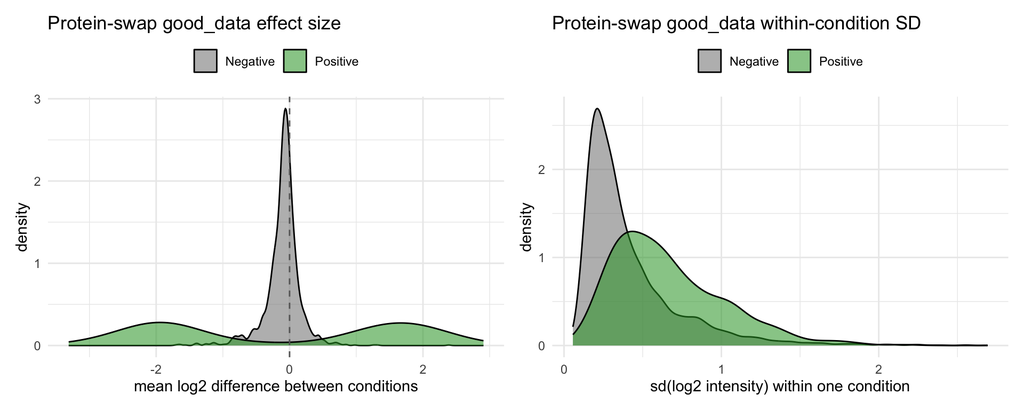

Explicit protein-swap benchmark, good_data. Intensities are direct report-derived protein/run summaries: log2 FG.Quantity values averaged from precursor to protein level within each run. Positives are matched protein-pair members; Negatives remain near the null. The SD density shows condition-specific within-condition SDs, not a pooled summary. The broader Positive SD distribution is compatible with regulated proteins being more heterogeneous than null proteins.

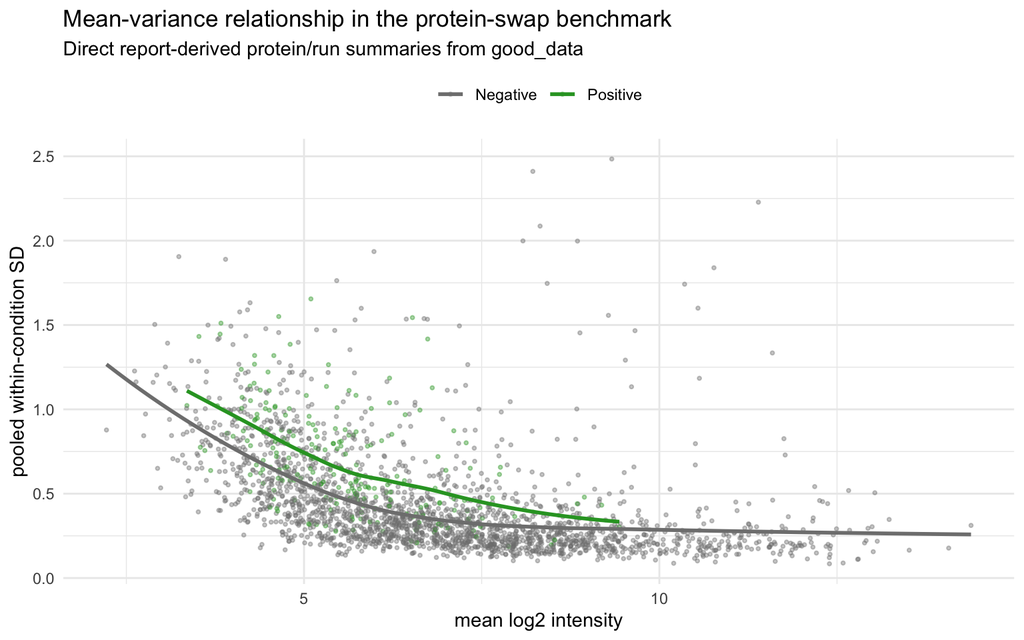

Explicit protein-swap benchmark, good_data. Each point is one protein summarized from the direct report-derived protein/run matrix. The y-axis is the pooled within-condition SD, used here only to place one variance summary per protein. Unlike the authors’ sample-swap benchmark, the null/Negative class is not forced into a higher-variance dilution mixture.

## 6.1 Protein-swap Dataset Composition

The protein-swap dataset names refer to run subsets, not to different protein-truth definitions. The same conservative 2,244-protein truth universe is used throughout. What changes between `all_data`, `good_data`, `small`, and `small_good_data` is which CSF injections enter the modelling step.

In the protein-swap benchmark, the Positive and Negative classes are defined by the protein-pair swap, not by the sample dilution. The table below describes the original run composition of each subset. `Condition1` and `Condition2` are the two model groups; `Good` and `Bad` are the sample-quality labels inherited from the original CSF annotation.

- `all_data` contains the full available CSF design: the Good Neat and 1:2 runs plus the higher-dilution Bad runs.
- `good_data` contains only Good Neat runs, so any differential signal comes from the protein swap rather than from the dilution design.
- `small` is a smaller mixed subset containing Good Neat/1:2 runs and a few Bad higher-dilution runs.
- `small_good_data` is the small Neat-only subset, four runs in each model group.

Run composition of the CSF_Spectronaut_protein_swap dataset subsets.

| Dataset | Sample label | Dilution | Group 1 / Condition1 | Group 2 / Condition2 | Total |
| --- | --- | --- | --- | --- | --- |
| all_data | Bad | 1to2 | 0 | 2 | 2 |
| all_data | Bad | 1to4 | 1 | 1 | 2 |
| all_data | Bad | 1to8 | 1 | 1 | 2 |
| all_data | Bad | 1to16 | 1 | 1 | 2 |
| all_data | Bad | 1to32 | 1 | 1 | 2 |
| all_data | Bad | 1to64 | 1 | 0 | 1 |
| all_data | Good | Neat | 8 | 7 | 15 |
| all_data | Good | 1to2 | 8 | 6 | 14 |
| good_data | Good | Neat | 8 | 7 | 15 |
| small | Bad | 1to4 | 1 | 0 | 1 |
| small | Bad | 1to8 | 1 | 1 | 2 |
| small | Bad | 1to32 | 0 | 1 | 1 |
| small | Good | Neat | 2 | 2 | 4 |
| small | Good | 1to2 | 1 | 1 | 2 |
| small_good_data | Good | Neat | 4 | 4 | 8 |

## 6.2 Protein-swap all_data, log2

Protein-swap benchmark: all_data/log2.

| Package | N | TPR_raw_p | PPV_raw_p | TPR_FDR | PPV_FDR |
| --- | --- | --- | --- | --- | --- |
| MSstats | 2201 | 0.755 | 0.982 | 0.274 | 1 |
| MSstats+ | 2200 | 0.867 | 0.995 | 0.678 | 1 |
| MaxLFQ_limma | 2201 | 0.849 | 0.978 | 0.472 | 1 |
| DEqMS | 2201 | 0.783 | 0.976 | 0.368 | 1 |
| msqrob2 | 2201 | 0.873 | 0.979 | 0.608 | 1 |
| prolfqua | 2201 | 0.868 | 0.974 | 0.604 | 1 |
| limpa | 2201 | 0.670 | 0.993 | 0.165 | 1 |

## 6.3 Protein-swap all_data, median

Protein-swap benchmark: all_data/median.

| Package | N | TPR_raw_p | PPV_raw_p | TPR_FDR | PPV_FDR |
| --- | --- | --- | --- | --- | --- |
| MSstats | 2201 | 0.821 | 0.983 | 0.627 | 1.000 |
| MSstats+ | 2200 | 0.891 | 0.940 | 0.810 | 1.000 |
| MaxLFQ_limma | 2201 | 0.915 | 0.882 | 0.797 | 0.994 |
| DEqMS | 2201 | 0.854 | 0.892 | 0.689 | 1.000 |
| msqrob2 | 2201 | 0.929 | 0.891 | 0.854 | 0.995 |
| prolfqua | 2201 | 0.892 | 0.851 | 0.788 | 0.994 |
| limpa | 2201 | 0.948 | 0.901 | 0.858 | 0.995 |

## 6.4 Protein-swap small, log2

Protein-swap benchmark: small/log2.

| Package | N | TPR_raw_p | PPV_raw_p | TPR_FDR | PPV_FDR |
| --- | --- | --- | --- | --- | --- |
| MSstats | 2199 | 0.156 | 0.825 | 0.000 | NA |
| MSstats+ | 2199 | 0.171 | 0.818 | 0.000 | NA |
| MaxLFQ_limma | 2201 | 0.203 | 0.896 | 0.005 | 1 |
| DEqMS | 2197 | 0.138 | 0.935 | 0.000 | NA |
| msqrob2 | 2201 | 0.198 | 0.913 | 0.000 | NA |
| prolfqua | 2201 | 0.193 | 0.732 | 0.000 | NA |
| limpa | 2201 | 0.090 | 0.950 | 0.000 | NA |

## 6.5 Protein-swap small, median

Protein-swap benchmark: small/median.

| Package | N | TPR_raw_p | PPV_raw_p | TPR_FDR | PPV_FDR |
| --- | --- | --- | --- | --- | --- |
| MSstats | 2199 | 0.374 | 0.760 | 0.000 | NA |
| MSstats+ | 2199 | 0.479 | 0.808 | 0.005 | 1.000 |
| MaxLFQ_limma | 2201 | 0.604 | 0.663 | 0.203 | 0.956 |
| DEqMS | 2201 | 0.448 | 0.629 | 0.085 | 0.947 |
| msqrob2 | 2201 | 0.642 | 0.705 | 0.189 | 0.909 |
| prolfqua | 2201 | 0.561 | 0.676 | 0.146 | 0.912 |
| limpa | 2201 | 0.566 | 0.764 | 0.052 | 1.000 |

## 6.6 Interpretation Of The Protein-Swap Results

The available protein-swap results support a narrower interpretation of the benchmark. In this construction, the null/Negative proteins are not made artificially more variable by mixing dilution levels inside a condition. Once that sample-swap variance asymmetry is removed, methods that use variance shrinkage or p-value moderation are no longer systematically disadvantaged. They are often comparable to, and in several cells better than, the MSstats+ row.

The smaller `small` subset should be read more carefully. With nominal `log2` normalization, all methods lose sensitivity because the sample size is small, but the `msqrob2` row is not a clean log2-only comparison: the current msqrob2 pipeline applies additional median centering internally. I therefore do not use that row as evidence for a pure log2 advantage. With explicit `median` normalization, MaxLFQ+limma, msqrob2, prolfqua, and limpa all exceed MSstats+ in raw-p TPR, and the moderated methods also dominate the non-zero FDR detections. This supports the central point of the reanalysis: the CSF Table 1 advantage alone does not establish a general property of the modelling problem. It depends strongly on a benchmark construction that couples the ground-truth label to different variance regimes.

# 7 Points To Raise With The Authors

The following points are intended as inputs for the article and accompanying materials in `manuscript_materials_second_submission`, not as private notes on this reanalysis. Items 1-5 are core asks tied to the variance-coupling concern and should be addressed for revision. Items 6-9 are constructive suggestions for the next version.

## 7.1 Core asks (variance-coupling concern)

1. **Protein universe definition.** The manuscript-style CSF benchmark uses an 1,820-protein truth list. The rebuilt sample-swap and protein-swap workflows use a stricter 2,244-protein universe after the `n_precursors >= 2` filter. The manuscript should state the filtering rules for each benchmark and justify why each universe is appropriate for comparing methods.
2. **Thresholding convention.** The conclusions are sensitive to whether the table is read at raw `p < 0.05` or adjusted `p < 0.05`. The manuscript should make the thresholding convention explicit wherever benchmark tables are interpreted.
3. **Dependence on swap construction.** The sample-swap design creates label-linked variance asymmetry in CSF. I view this as a firm benchmark-design concern for interpreting Table 1, not merely as a minor implementation detail. The authors should clarify whether MSstats+ is expected to improve specifically under this sample-swap variance asymmetry, or more generally across independent synthetic and biological benchmark constructions.
4. **Separate benchmark creation from tool benchmarking.** The manuscript and archive should separate the code that creates a benchmark dataset from the code that benchmarks tools on that dataset. A benchmark should be written to disk as an explicit report plus annotation/truth files, and all modelling tools should then consume that fixed dataset. This makes the benchmark auditable and prevents method-specific analysis code from depending on the benchmark-generation code path. This is the structure used in the rebuilt sample-swap and protein-swap analyses here.
5. **Normalization and estimand.** The K562/CSF dilution benchmarks are also difficult settings for standard normalization comparisons. TIC, median, quantile, and VSN-style normalization can be appropriate in ordinary proteomics workflows, but in this benchmark they may change the estimand because the raw Neat versus 1:2 comparison is deliberately a total-material difference and the post-swap data are dominated by the manufactured Negative class. The manuscript should clarify whether comparator methods are being evaluated under their normal best-practice workflows or under constraints imposed by the benchmark construction.

## 7.2 Additional suggestions for the next version

6. **Comparator workflows and benchmark venue.** Because the manuscript makes a comparative method-performance claim, the authors should consider engaging with developers or maintainers of comparator workflows such as `msqrob2`, `prolfqua`, and `limpa`, and with community benchmarking efforts such as ProteoBench. This would help distinguish MSstats+-specific gains from choices about benchmark construction, normalization, and method-specific workflow configuration.
7. **Runtime reporting.** The manuscript should report timing information for each tool and benchmark cell. In this reanalysis the observed runtimes differ substantially between tools and between datasets; without timing information, the reader cannot judge the practical cost of the reported performance.
8. **Memory reporting.** The manuscript should also report memory usage or peak memory ranges for each tool. Runtime alone is not sufficient for practical reproducibility, especially for methods that fit many protein-level models or require large intermediate objects.
9. **Include prolfqua.** The benchmark should include `prolfqua` as an additional contemporary modelling workflow. It is directly relevant to the comparison because it provides an independent implementation path for protein-level differential analysis and helps separate MSstats-specific behaviour from more general properties of moderated and non-moderated workflows.